# Week 07 - Regression

# OK - now easy peasy, use your normal equations.

```r
#Use normal equation (X'X)-1 * (X'Y)
XX=t(Xd2)%*%Xd2
XY=t(Xd2)%*%Y
B=solve(XX)%*%XY
print(B)
```

```
##            [,1]
##    -64.34207893
## X1  -3.33359131
## X2   0.05982059
## X3   1.65209291
```

Great - how can we plot this?

Just calculate Yhat, and plot Y vs Yhat

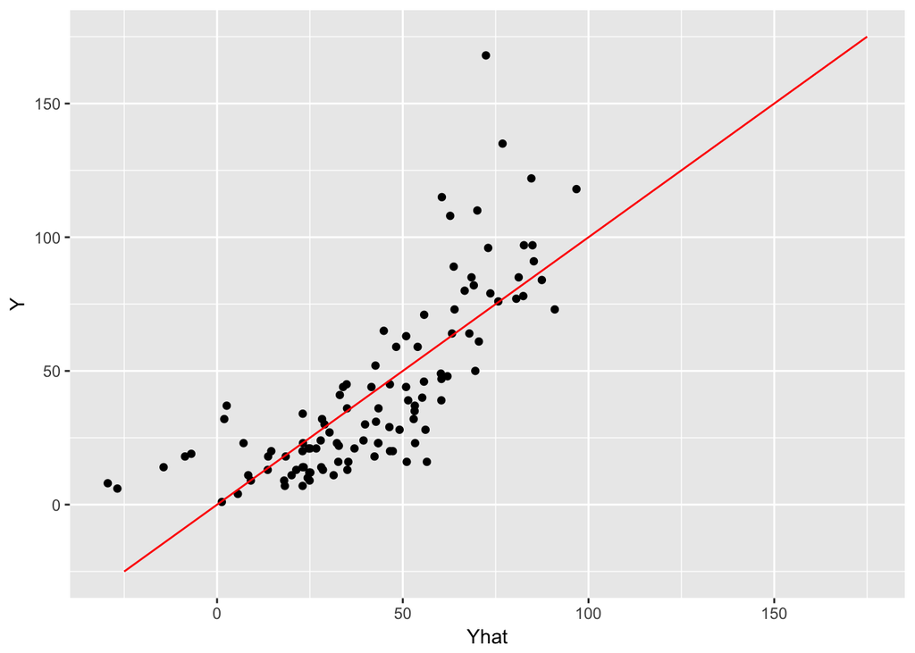

```r
Yhat = Xd2%*%B
ggplot()+geom_point(aes(Yhat,Y))+geom_line(aes(c(-25,175),c(-25,175)),colour = "red")
```

How about uncertainty? It’s also the same.

```r
#UNCERTAINTY IS DONE THE SAME WAY
residuals = Y-Yhat
SSE = t(residuals)%*%residuals
MSE = SSE / (length(Y)-length(B))
#Now moving forward we want the root mean square error (RMSE) or s .
s = sqrt(MSE)
covB = solve(t(Xd2)%*%Xd2)*as.vector(s^2)
stdB = diag(sqrt(covB))
stdB
```

```
##                      X1          X2          X3
## 23.05472435  0.65440710  0.02318647  0.25352979
```

Which of our variables is most important? Depends how you define it…

We could look at the ratio of the coefficients to their standard deviations…

```r
B/apply(Xd2,2,sd)
```

```
##             [,1]
##             -Inf
## X1 -0.9370039347
## X2  0.0006562708
## X3  0.1733576355
```

```r
#or we could look at the ratio of the standard errors to the coefficients - this tells us something different though
stdB/B
```

```
##          [,1]
##    -0.3583149
## X1 -0.1963069
## X2  0.3876001
## X3  0.1534598
```

```r
#Or we could model each individually, and see which has the smallest standard errors...
```

There’s still a curve in those data that we’re not capturing…

Perhaps we think that we could model Ozone better with a 2nd-order polynomial of windspeed than a line.

$Y = b_0 + b_1x + b_2x^2$

Easy now, we just set up a new design matrix:

```r
Xd3 = cbind(ones,X1,X1^2)

#Use normal equation (X'X)-1 * (X'Y)
XX=t(Xd3)%*%Xd3
XY=t(Xd3)%*%Y
B=solve(XX)%*%XY
print(B)
```

```
##           [,1]
##    166.7662893
## X1 -19.9586495
##      0.6620691
```

And calculate our predictions and plot..

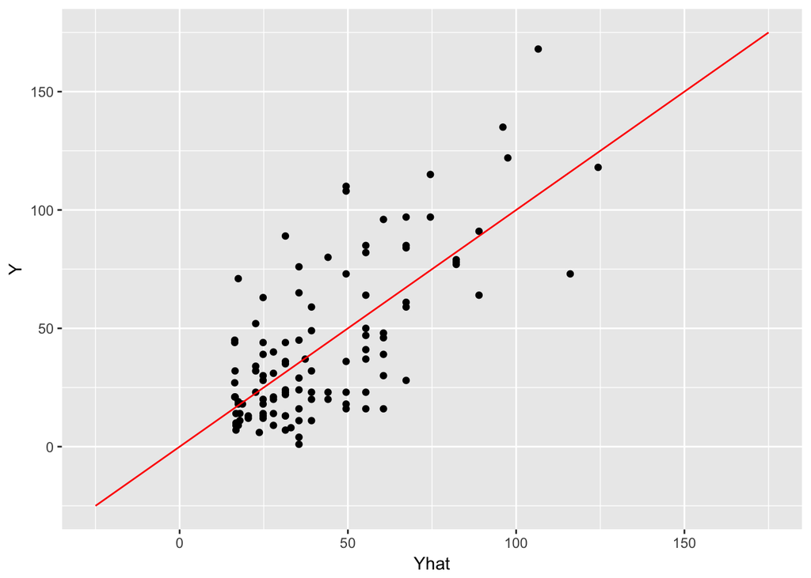

```r
Yhat = Xd3%*%B
ggplot()+geom_point(aes(Yhat,Y))+geom_line(aes(c(-25,175),c(-25,175)),colour = "red")
```

```r
#UNCERTAINTY IS DONE THE SAME WAY
residuals = Y-Yhat
SSE = t(residuals)%*%residuals
MSE = SSE / (length(Y)-length(B))
#Now moving forward we want the root mean square error (RMSE) or s .
s = sqrt(MSE)
covB = solve(t(Xd3)%*%Xd3)*as.vector(s^2)
stdB = diag(sqrt(covB))
stdB
```

```
##                    X1
## 14.3437613  2.7412814  0.1240971
```